# 分子遺伝学～多様性の分子遺伝学～

ryamada

2018年1月30日

# 1 イントロダクション

この文書は、全学共通科目「分子遺伝学」のうちの９０分ｘ５回の講義の補助資料です。

遺伝現象を分子生物学の側面から理解することの基礎を学びます。

もっとも大事なことは

- 遺伝現象は、「親子関係」があるときに、「個体が似通った特徴を提示する」ことを指していること
- 遺伝現象は、「情報を担う分子」が「物理的に伝達」されることで引き起こされること
- 「伝達」と「提示」とが、「確率的」に起きること
- その結果、生物には確率的多様性があり、その多様性が生物の本質のひとつであること

を理解することです。

## 1.1 基本用語の整理

複数の個人を集めてきて、身長を測ると、いろいろな数字が得られます。

身長は個人のある性質(属性)であり、「形質」と呼びます。値がいろいろな実数値をとるので「量的形質」と呼びます。

量的形質である身長が、170cmであるとき、170cmは、身長という形質の「表現型(ひょうげんけい)」です。

個人の属性には、性別もあります。性別も「形質」です。 値が、「男か女か」の２つの値を取るので、「二値型形質」と呼びます。「質的形質」とか「カテゴリカル形質」とも言えます。

「男」と「女」はいずれも「表現型」です。

ある細胞の体積が大きい・小さいというのも、細胞の属性であり、細胞の「体積」が「形質」で、その「体積の値」は「表現型」です。

細胞が「癌細胞」か「正常細胞」かというのも、細胞の属性であり、「癌化の有無」が「形質」で、「癌である」「正常である」は「表現型」です。

### 1.1.1 遺伝子と遺伝子型

個人や個々の細胞の属性を説明するのに、「形質」とその「表現型」という用語を使いました。

遺伝学では、遺伝子の方にも対応する用語(「遺伝子」と「その型」)を使います。

#### 1.1.1.1 遺伝子とは

では、「遺伝子」とは何なのでしょう。

- 「遺伝子とは、DNAのことでしょう。そしてタンパク質を塩基配列としてコードしているもののことです」

そうかもしれません。 ですが、メンデルの遺伝の法則は遺伝子の存在を想定していますが、DNAや塩基配列は知られていませんでした。 その頃も「遺伝子」という概念はありました。 したがって、遺伝子とはDNA配列のこと、という説明ではなく、「遺伝子の本質」について 遺伝子は「遺伝現象(親子が似る)」を引き起こす「子～単位」となる何かのことです。

#### 1.1.1.2 形質と遺伝子

ごく大雑把に言うと、親から子に形質が遺伝するが、形質ごとに、その形質の伝達を司る遺伝子がありそうだ、と考えます。 たとえば、「身長という形質を司る遺伝子」「性別という形質を司る遺伝子」のように、「形質を司る遺伝子」がある、という発想です。

DNA分子が持つ、塩基配列がタンパク質のアミノ酸配列を決定しており、タンパク質には機能があり、その機能が形質に影響を与えることがわかっている現代では、以下のように考えます。

- 長大なDNA分子のある特定の小範囲の塩基配列が、タンパク質のアミノ酸配列を決定しており、そのタンパク質が機能を持っていて、表現型を決めていると考えています
- そのため、遺伝子と言えば、特定の情報をコードしている、単位的なDNA分子のある一部分を指す、と考えられています

しかしながら、身長に影響するいわゆる遺伝子は多数あることなどからも解るように、「形質」と「いわゆる遺伝子」との関係はそれほど単純ではありません。

また、身長のように、簡単に観察できる形質もあれば、「肝臓の細胞の毒素分解能力」のように、属性だけれど、測定が一筋縄ではない形質もあります。

したがって、遺伝子とは何かについては、次のように抽象的に定義しておくことが望ましいです。

- 「親から子へと(生殖活動を通じて)伝達される」「物質とその状態」であって、「何らかの意味で」、「形質に影響を与える情報」を有しているものの「総体」が「遺伝情報(の全体)」である。その総体としての遺伝情報の一部分が「単位として切り取り可能な・切り取ることに意味のある遺伝情報の小構成要素」とみなせるとき、それを「遺伝子」と呼びます。
- 上記の定義に照らすと、DNA分子には多数の遺伝子が乗っていることになるが、それ以外にどのような「遺伝子」があるかは、不定・未定である、ともみなせます。

#### 1.1.1.3 遺伝情報の離散性

なぜ、子が親に似るのかを説明しようとしたとき、両親のそれぞれの「あり様」が混ざり合ったものが伝わると考えることもできました。 この混ざり合いが絵具の混色のようなものだと、赤はいったん青と混じって紫になると赤に戻ることはありません。もしも、赤が最適であったとしても、突然変異で生まれた赤は少数派なので平均化されて赤が席巻することは難しそうです。

また、メンデルの豆の実験のように、「しわあり」と「しわなし」の次世代はすべて「しわなし」となり、その次の世代で「しわあり」が復活することも、遺伝情報が絵具の混色とは違うことを示唆します。

このようなことを考え合わせると、遺伝情報は離散性を持っているのではないかと思われていたわけですが、実際、DNAの塩基配列が情報を担っているとわかってみると、遺伝情報の離散性と符号していました。

#### 1.1.1.4 遺伝子型

形質に表現型があったように、遺伝子には遺伝子型があります。

形質は個人の属性で、表現型は属性の取りうるいろいろな値のことでした。

遺伝子は「遺伝情報の一部分」で、遺伝子型はそのいろいろな値のことになります。

遺伝子を特定範囲のDNAの塩基配列とすれば、遺伝子型は、DNA配列のバリエーションのことになります。

この遺伝子のバリエーションを「アレル」と呼ぶこともあります。

ここで言うところの、「遺伝子」と「アレル」は、「遺伝子座」と「対立遺伝子」と呼ばれることもあります。

### 1.1.2 Hereditary と genetic

遺伝を考えるにあたって、形質が似るという意味での遺伝現象と、それを支える遺伝子という概念を説明しました。

これらは日本語ではいずれも「遺伝的な」と言いますが、英単語には２つあります。

- Hereditary
- Genetic

の２つです。

一般用語としてのHereditary, Geneticとは別に、遺伝学用語としては次のような使い分けがあります。

- Hereditaryは表現型が親子で似るという「現象としての遺伝 Inheritance」の形容詞形
- Geneticは、親から子へ伝達される「物質とそれが持つ情報」の形容詞形。または、「物質とそれが持つ情報の単位」である「遺伝子 gene」の形容詞形

# 2 生命の起源と進化(と分子系統樹)

ヒトはどこから来たのか、という問いへの説明として、

- ヒトは陸上の生物であるけれど、大昔は、水中にしか生物は居なかったが、陸上生活に適応した
- ヒトは恒温動物であって、周囲の温度によらず体温を一定に保つ仕組みを持っているが、変温動物から進化した
- ヒトは多細胞生物であるが、多細胞生物は単細胞生物から進化してきた
- 原始には生物はなく、いつからか生物という仕組みが生じ、それが変化を続け、今に至っている

という話は聞いたことがあるでしょう。

現存の生物種を比較したり、化石を研究したりすることで得られた理解と推測です。

分子遺伝学では、この進化を遺伝子のレベルで理解しようとします。

## 2.1 生命の基本的な仕組みとしての遺伝・遺伝子

生命とは何か、という問いへの答えはいろいろなものが考えられますが、遺伝学・分子遺伝学の枠組みで言えば「遺伝現象を伴う系」もそのひとつと言えます。

遺伝現象を成立させるのは、「親子」という時間軸上の関係と、親から子への、「情報」の受け渡しが必須です。

逆に言えば、情報の伝達を伴う親子関係が面々と繋がることが、遺伝学・分子遺伝学の立場での、生命の基本です。

### 2.1.1 情報とその伝達

情報が情報として機能するためには、物質に情報が書き込まれていて、それを読み取る仕組みも必要です。 さらに、情報の伝達のためには、情報を担った物質のコピーが作れなくてはなりません。

## 2.2 セントラルドグマと生命の基本的な仕組み

DNAの上に情報が乗っており、その一部を読み出してmRNA分子が作られ(転写)、その情報をアミノ酸配列に変換します(翻訳)。

「DNA->RNA->タンパク質」という３タイプの化学物質の一方向性の関係が生命の基本(ドグマ)である、とするのが、セントラルドグマです。

生命の基本的な仕組みに照らして説明しなおすと次のように書けます。

- DNA分子はATGCを使って文字列として情報を担う
- DNA分子はコピーされる
- DNA分子はタンパク質の情報をコードしており、タンパク質は酵素としてDNA分子のコピーという仕事を担う
- mRNAはDNA分子からタンパク質を作る途中の分子である。tRNAはタンパク質を作るときにmRNAとアミノ酸とをつなぐ仕事を担う。rRNAはアミノ酸をつなぐ装置を構成する

## 2.3 RNAワールド仮説

「DNA->RNA->タンパク質」という３種類の分子が生命の基本的な仕組みを担っています。 ひとたび、この仕組みが出来上がれば、その仕組みをDNAという情報性物質に「教えて」、次世代に受け継ぐことはできそうです。

しかしながら、仕組みは少しばかり複雑なので、最初にいきなりこの仕組みが「ぽん」と出来上がって、それを生命の起源と考えるのは、難しそうです。

では、どれくらいなら仕組みを簡単にできるかを考えて見ます。

- RNA分子はAUGCを使って文字列として情報を担うことができる
- RNA分子はコピーされうる
- RNA分子は高次構造をとることができて、高次構造をとると、それはタンパク質と同じように酵素としてRNA分子のコピーという仕事を担うことができる

このように書き換えれば、RNAのみで生命の基本的な仕組みを実現することが可能なように見えます。

このようにDNAとタンパク質のないRNAだけの世界が、現在の「DNA->RNA->タンパク質」の世界の前に存在していたのではないか、とする仮設を「RNAワールド仮説」と言います。

## 2.4 エントロピーと情報

エントロピーを用いて生命と非生命との違いを説明することもあります。

非生命の現象は、ほうっておくと乱雑な状態になるのに対して、生命現象では、複雑な秩序や構造が維持・構築されるという違いがあります。 放っておくと、乱雑になることをエントロピーの増大と言い、そのことを熱力学の第二法則と言います。

生命現象では、あたかも熱力学第二法則に反しているかのようだ、というわけです。

生命現象でも、構成する分子・物質が物理・化学反応をしているわけなので、当然、熱力学第二法則は成り立っているのですが、そう見えないのです。

これはどうしてなのでしょうか。

その鍵のひとつが情報です。

乱雑というのは、何をどうするのかの決まり・情報がないので、なすがまま・なされるがままの状態に行き着いてしまった状態とも言えます。

DNA配列は情報を持ち、その情報を表現型として実現する仕組みに関する情報も持っていることによって、特定の状態を作り出し、乱雑な状態になることを避けています。

また、DNAは修復機構を持ち、コピーを作る仕組みを有することで、情報の劣化をも防いでいます。 これは、情報のための仕組みとして非常に優れたものであることも知られています。

実際、大規模なデータを計算機用の記録メディアで保管するよりも、その情報をDNA配列にして、そのコピー・修復機構とともに保持しておくことが、大量のデータの安定的保管方法として着目されていることからもわかります。( https://wired.jp/2016/05/06/microsoft-experiments-with-dna/ )

### 2.4.1 エントロピーの計算

遺伝学は、生物学の中で非常に数学・情報学との関係が強い分野なので、数式も使うことにします。

エントロピーは熱力学における概念として知られていますが、情報学においてもエントロピーは用います。

確率事象があって、その生起パターンがk通りあり、その生起確率が$P={p_1,...,p_k}; \sum_{i=1}^k p_i=1$であるとき、エントロピー(平均情報量)は

$$H = \sum_{i=1}^k -p_i \log{p_i}$$
と定義されています。

今、k=2の場合、○か×かの場合を考えます。

○の確率pが小さい場合と、逆に大きい場合には、エントロピーは小さく、$p=0.5$と、○か×か、まったく見当がつかない場合に、エントロピーは大きくなります。

このようにエントロピーは「てんでんばらばらのときに大きく」「(○にしろ×にしろ)ばらばらでないときに小さく」なるようなものです。

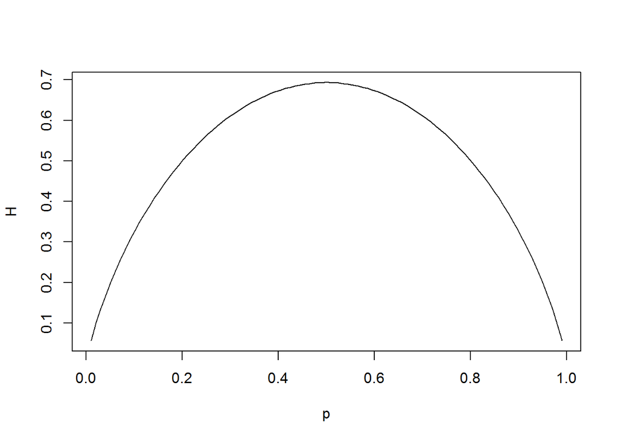

一方、次のような考え方もします。

「ビッグニュース！」の情報の量を起きた事件の珍しさで定義します。 その事件が起きる確率がpであるとき、そのニュースの情報量を

$$-\log{p}$$
とします。

このようにエントロピーと情報という視点から、生物の仕組み、遺伝情報の意味を考えると次のように言えます。

- 生物は、情報がなかったら、無秩序になってしまうところを、情報を使って、特定の状態に維持する仕組みを持っています。特定の情報は、熱力学第二法則の下では、とても起きにくい珍しい状態であるという意味で、エントロピーが低い状態です。そしてエントロピーを低く保つ鍵である情報は、放っておくと劣化してしまうのですが、それを劣化しないように、コピーを作り、更新する(細胞分裂・世代交代する)仕組みも持っています。

## 2.5 進化と多様性

- 進化とは、生物の形質が時間とともに世代を経る中で変化して行く現象のことです。

生命の基本的な仕組みとは、

- 情報性分子があって
- それがコピーされる

と学びましたが、これに加えて

- 増えること
- 変化すること

もあります。 そして、変化しながら増えると

- 多様性を持つ

ことになります。

ここで言う、多様性には、遺伝子型の多様性もあれば表現型の多様性もあります。

## 2.6 種と種分化

有性生殖生物(動物)の場合、配偶子が合体して受精卵ができ、それが細胞分裂をし、新たに配偶子を作成できることで、種は継続することができます。

遺伝子のレベルで言えば、配偶子(１倍体)の作成のための減数分裂、配偶子が合体してきちんとした２倍体となり、細胞分裂に際して遺伝子セットがコピーされて、きちんと分配される必要があります。

１倍体・２倍体、遺伝子コピーの作成、均等分配というプロセスでは、 相同染色体が合い並ぶこと、それらがきちんと分離することが要求されます。

したがって、染色体の数が等しく、それぞれの染色体を構成するDNA分子がきちんと並ぶ程度には配列が等しい必要があります。

逆に言うと、染色体数が等しければ、それぞれの染色体を構成するDNA配列はある程度異なっていても、種の存続と言う観点からは問題ないことがわかります。

実際、異なる種のオスとメスとを掛け合わせて仔が生まれることはあります。 たとえば、オスのロバとメスの馬とを掛け合わせて生まれる、ラバがあります。 ラバを種と呼ばないのは、その仔が不妊である(その仔同士から配偶子が作られ、新たな受精卵を成し、次世代の仔が生まれない)ためです。

また、配偶子・受精卵、遺伝子・染色体のコピー・分配という点では問題がなくとも、表現型の問題で仔をなせない場合があるでしょう。たとえばセントバーナードとチワワとは交尾上の問題・子宮内発生上の問題があります。しかしながら、人工授精等の技術を使えば、体格的に大きく異なる２つの犬種(々犬という種のバリエーション)との「子」は生まれ、その子は生殖能力があるので、この場合は、セントバーナードもチワワも同じ種となります。

## 2.7 進化系統樹

進化では、新種が生まれ、種が分かれます(種分化)。 その背後には、DNA配列の変化、染色体構造の変化があります。

新種の誕生、種分化を図で示すと、進化系統樹ができます。

## 2.8 ゲノム進化

進化をゲノムの変化という点で考えて見ます。

ゲノムは、DNA分子の有りよう全体のことです。

ゲノムは複数のDNA分子のセットになっていますから、 ゲノムの変化は、個々のDNA分子に刻まれた塩基配列の変化と、それが何個の分子にどのように配されているかの変化とからなります。

特に、「遺伝子」は遺伝情報の構成単位であって、DNA分子上の特定の位置にある塩基配列と見ることもできるので、 ゲノムの変化は、個々の遺伝子の塩基配列の変化と、遺伝子の並び方の変化と、全遺伝子の複数の染色体への分配の仕方の変化として捕らえることができます。

## 2.9 遺伝子変異

### 2.9.1 変異と変異体と多様性

DNA配列が変わる出来事を「変異 mutation」と呼びます。

「変異 mutation」が起きることで新たに生じた配列を持つDNA分子を「変異体 mutant」と呼びます。 新たに生じた配列を持つDNA分子を持つ個体も「変異体 mutant」と呼びます。 また、異なるDNA配列を持つ分子・それを保有する個体を「多様体 バリアント variant」とも呼びます。

DNA配列が分子によって異なるとき、その「異なっているよ」ということをさして、「多様性 バリエーション variation」と呼びます。

明治以来の訳語の変遷、学問グループ間での違いなどから、用語が混乱しているので、本などを読むと混乱しますので、「事件」なのか「状態」なのか「その結果生じたモノ」なのかを意識して呼びわけるようにすることが大切です。

医学系(日本人類遺伝学会)では、以下のように定めています。

http://www.tufu.or.jp/bbs/2009/009.html http://jshg.jp/wp-content/uploads/2017/08/d5fdc84ae83d3a9a6627b7ac249e4db0.pdf

### 2.9.2 遺伝子変異の分類

遺伝子変異は配列の変わり方のタイプと、その規模との２つの側面で分類します。

- 遺伝子変異のタイプ
- 置換型変異
- 挿入と欠失型変異
- 重複型変異
- 転座型変異
- 逆位型変異
- 遺伝子変異の大きさ・規模
- 1塩基対単位から、1000塩基対単位、そしてもっと長く
- 遺伝子単位での重複
- 染色体規模での変化
- 全ゲノム重複

いずれのタイプにも、さまざまな規模の変異があります。

### 2.9.3 種間のゲノムの違い

小規模な変化が少数集まっただけでは、種の違いをもたらしません。 小さな変化であれば、それは個体ごとのゲノムの違いであって、メイティングが可能だからです。

もともと同一種であったものが、何かの事情で相互に隔離されると、それぞれの隔離された集団内で変異が起こり、それが積み重なり、メイティングできないほどの違いになるようなことがあれば、それは種分化をもたらしたことになります。

ひとたび、メイティング不能となれば(種分化すれば)、その後は、それぞれの種の個体集団の中で独自の変異が蓄積し、ゲノムの状態の違いはどんどん広がる一方となります。

実際、遺伝子の並び順と染色体への分配のされかたが、種間で異なってくるために、シンテニーという状態が生じていることが観察されます。

ヒトとマウスとは、ともに哺乳類なので、種分化は比較的最近だと考えられます。したがって、個々の遺伝子のDNA配列はよく似ています。 その似ている部分はいくつもの断片に分けることができて、その断片のモザイク状態がヒトとマウスでは違います。

また、種の違いは、全ゲノム重複と呼ばれるものすごく大規模なゲノム構成の変化や、染色体構成の変化(染色体が分かれたり、融合したりして、染色体の本数・長さ・構成が変わること)などに現れてきます。

全ゲノム重複では、DNA量が倍に、個々の遺伝子も倍になるわけですが、倍になる前の種がうまく環境に適応して栄えているときには、倍になった種・個体は環境に適していないことが多そうに思えます。 それは、ヒトの場合に最も小さい21番の常染色体が２本ではなくて３本になると、ダウン症候群という病気になります。 いろいろな「「不具合と見える」症状が出ることからも想像ができます。

しかしながら、環境というのは一定ではないので、大きな変化の結果として生じた種がより適応し、繁栄することもあったのだろうと推測されますが、DNA配列を比較することで、全ゲノムレベルでの重複が複数回あったと考えられています。

## 2.10 配列の似た遺伝子、ホモログ・パラログ・オーソログ

ゲノム構成の粗大な違いが種間にあることがわかりました。

しかしながら、個々の遺伝子に目を向けると、重要な機能を持つ遺伝子は進化の過程で保存され、多くの種が保有していることも確認できます。

長い進化の歴史の上では、膨大な塩基配列が試行錯誤され続け、稀に、有効な塩基配列が生じたと考えられます。そのようにして得られた塩基配列は、進化が続く中でも複製され、次世代に伝達され、大切に保持されてきました。

また、ひとたびうまくできた塩基配列はコピーされ、複数のコピーが同一のゲノム上に存在することもしばしばあります。

コピーされた配列は変化することなく、まったく同じ配列として置かれていることもありえますが、実際には、塩基配列が異なっています。

もしもコピー配列がない場合には、せっかくうまくできている塩基配列を変えることは、生存を脅かしかねない大きな挑戦になります。 しかしながら、複数あれのであれば、１つを変えずにおけば、残りには思い切った変化が起きても、生存までは脅かさないかも知れませんがら、「だめでもともと」な変化を起こすことができるかも知れません。 そのような配列変化により、遺伝子としての機能がなくなることもありますが、新しい機能を獲得することもあるでしょう。

機能している遺伝子と似たような配列を持ちながら、遺伝子として発現しない・機能しない遺伝子は「偽遺伝子」と呼ばれます。

このように、元はひとつのDNA配列であったものが、同一種の中に複数のDNA配列として存在し、相互に配列がよく似ているとき、それらは相互にパラログである、と言います。

また、元はひとつのDNA配列であったものが、種分化し、よく似ているが異なる配列となっているとき、相互にオーソログであると呼びます。

同一種内か、種間かの違いはありますが、どちらもDNA配列がよく似ているので、それらを合わせて、ホモログと呼びます。

## 2.11 分子時計

過去に同一の種だったものが、進化の過程で、１回種分岐し、その片方が、現在の種Aとなり、もう片方はさらに時間が経過した後にもう一度種分岐し、現在の種BとCとなったとします。

この３種に共通するパラログ遺伝子のDNA配列を比較することを考えます。

AとB、BとC、CとAの３つの比較の中で、もっともDNA配列が似ているのはどのペアになるでしょうか？

BとCとは、比較的最近種分化しており、AとBの種分化と、AとCとの種分化とは同じときにおきています。

したがって、BとCとのDNA配列がもっともよく似ているのではないかと推測できます。

配列が似ていれば、種分化からの時間は短く、似ていなければ、長いだろうと考えることで、DNA配列の比較から、種分化までの時間の長短を推定することができそうです。

それができると、進化系統樹の形を推定することもできるでしょう。

DNA配列の比較を種分化からの経過時間の指標とすると説明しましたが、経過時間の指標になるのはDNA配列の異同だけではありません。DNA配列がコードしているタンパク質のアミノ酸配列の異同も指標になります。

DNA配列もアミノ酸配列も、進化の過程で変化する可能性がある分子であり、分子の配列の違いが種分化からの時間を教えてくれるという意味で、「分子時計」と呼ばれます。

### 2.11.1 分子時計のモデル～ポアッソン過程～

時間経過に伴って、ポツリ・ポツリとイベントが発生するとします。 イベントがいつ起きるかわからないけれど、単位時間中に起きるイベントの回数は平均 k 回だとわかっているとします。 また、個々のイベントは相互に無関係に・独立に起きるとします。

このような確率過程をポアッソン過程と言います。

自然界では、原子核の放射性崩壊がポアッソン過程であると知られています。

今、ある遺伝子に起きる「イベント」がDNA塩基配列の点変異であったり、アミノ酸配列のアミノ酸置換だとすると、そのイベントのすべてを記録することができて、すべてのイベントが独立に定常生起確率で起きていると仮定すれば、分子に起きたイベントの数は、種分化からの時間に比例すると予想されます。

実際、分子の配列を比較し、その異なる箇所を数え、その数をイベント数とみなしたとき、種分化からの時間(化石等の発掘年代推定などから割り出すこともできます)との関係には、かなりよい一次線形の正の相関があることが知られており、DNA配列・アミノ酸配列は分子時計とみなせると考えられています。

#### 2.11.1.1 保存性の良さ

上の分子時計のポアッソン過程モデルでは、DNA配列・アミノ酸配列の違いを数え上げてイベント数としています。

数え上げるということは、配列上の位置に関わらず「１回のイベント」として数えるということです。 それは、配列上の位置に関わらず、「単位時間あたりに起きるイベント回数」は等しいことを仮定していることでもあります。

本当にどのDNA塩基対もアミノ酸残基も等確率で変化するのでしょうか？

答えは否です。

２つのパラログな遺伝子が並んでいるとします。片方は生存に必須な遺伝子であり、もう片方は、偽遺伝子となっているとします。発現もしなければ機能もないということです。

２つの遺伝子はパラログですから、DNA配列は長さもほぼ同じで、よく似ています。

長い年月が経ったときに、どちらの遺伝子のDNA配列がより多くの塩基配列の違いを貯めているでしょうか。

答えは、偽遺伝子の方が多く変化している、です。

これは、単位時間当たりの平均イベント回数が大事な遺伝子より偽遺伝子の方が大きいことを意味します。

偽遺伝子では、どこにどんな変異が起きても、生物の機能には影響しないので、どんな変異も次世代に伝わります。

他方、大事な遺伝子の方は、終始コドンが発生してしまうような塩基配列変化は、たとえ起きたとしても次世代には伝わらないですから、その分、「次世代に伝わりうるイベント」の平均回数が偽遺伝子の場合より小さくなります。 終始コドンが発生しなくとも、アミノ酸置換が起きて、大きくタンパク質としての性質が変わるような塩基変異も次世代には伝わりにくいですから、この分も平均回数は小さくなります。

これが、両者の配列変化の貯まり具合の違いを生むメカニズムです。

- 大事なものは変わりにくい。大事でないものは変わりやすい

ということです。

コドンの３塩基のうち、１番目の塩基が置換型変異する場合と、３番目の塩基が置換型変異する場合とを比べてみます。 １番目の塩基の変異の方がアミノ酸置換を起こす確率は高いです。 したがって、置換型変異が次世代に伝達される確率は、コドンの１番目の方が３番目よりも低確率となります。

遺伝子には、エクソンとイントロンとがあります。エクソンに起きる変異はアミノ酸配列に影響する可能性がありますが、イントロンのそれは、なにかしらの機能影響をもたらす可能性はありますが、アミノ酸配列を変えることはないでしょう。

この違いから、エクソンにおきる単位時間当たりの平均回数はイントロンのそれより小さくなります。

染色体上には、いわゆるコーディング遺伝子領域(エクソンとイントロン、その上下流領域)とそれ以外の領域とがあります。

それ以外の領域にもさまざまな機能がありますが、総じて、コーディング遺伝子領域よりも重大度は低いです。 したがって、単位時間当たりの平均イベント回数が高くなります。

このようにDNA配列変化がもたらす機能の重大性が高い部分ほど、進化における配列の保存性が高くなります。

逆に、コーディング遺伝子領域以外であって、何の機能も知られていない領域があり、種間での配列保存性が周辺にくらべて高かったとすると、その領域には未知の機能があるのではないかと推測することもあります。

### 2.11.2 配列の比較とアラインメント

分子時計配列を比較して「イベント数」を数えるとよいのはわかりましたが、場合よっては、「イベント数」を数えるのが難しいです。

挿入・欠失型バリエーションがあるために、何番目の塩基(またはアミノ酸残基)と何番目の塩基(またはアミノ酸残基)とを比較すればよいかが簡単に決められない場合があるのです。

どことどこを対比させることにするのかを決める必要があり、その作業を配列のアラインメントと呼びます。

アラインメントはさまざまな基準で系統だって行う方法が提唱されており、バイオインフォマティクス分野の主要な課題であり、現在でも活発に研究が進められています。 このように活発に情報学的に研究される背景には、問題自身が複雑であることと、高速シークエンシング技術の発展に伴い、より高速で効率的なアルゴリズムが必要とされているからです。

一方、アルゴリズムにより適切なアラインメントを決めるという方向とは異なるアプローチになりますが、多数のヒトがゲーム攻略するようにアラインメント問題を解くという方法もあります。

## 2.12 自然選択説・中立進化説・ほぼ中立進化説

大小の変異が起きて、その結果、受精卵が発生しなかったり、個体は生まれても不妊であったりすることから、種が分化し、種内で遺伝的多様性が蓄積・拡散すれば、表現型多様性が生まれる。

多様な種の間でどちらかしか生存できない状況になると、ある種は残り、ある種は残らない。そのような自然の環境要因で選択された結果が進化の側面を説明するでしょう。

環境は一定ではないので、あるときに生き延びやすい表現型も、環境が変われば逆になります。したがって、多様性を持っている種の方が、環境の変化にも強いことが種としての存続を可能にしたこともあったと考えられます。

一方、どのような変異が集団内に蓄積するかを考えてみます。 個々の変異は偶然に起きるとすると、その変異はある条件に照らすと好都合であるのに対し、別の条件に照らすと不都合なものでしょう。 とはいえ、大多数の変異は有利とも不利とも言えない「中立」的な変異だと考えてみます。 そうすると、集団内に発生した「中立な」変異は、次世代・次々世代に伝達されるか、伝達されながら、集団内での割合が増えるか減るかも、ランダムに決まると考えるのが適当です。 このように考えると、集団内での新規のバリエーションの頻度は酔歩をするように上がったり下がったりをしそうです。この頻度が酔歩のように上がったり下がったりすることを「遺伝的浮動」と言います。

実際に集団がもつバリエーションの割合はそのような仮定のもとでのそれに良く似ていることから、分子の進化は「中立」だとするのが、「中立説」です。

ただし、集団に遺伝的多様性がある場合でも、集団が小さいと、何かの拍子に集団のすべての染色体が片方のタイプに固定してしまうことが起きやすくなります。そうすると、それ以降はそのバリエーションは集団から完全に失われます。 したがって、集団サイズが小さいと、変異の固定がより高頻度で起きることとなり、これは、進化を加速します。 また、集団サイズが大きいと、中立ではない変異はその有利・不利によってきちんとふるい分けされますが、集団サイズが小さいと、多少の有利・不利はあっても変異の固定がされやすくなります。この多少の有利・不利を持つ変異のことを「ほぼ中立な」変異と呼びます。

このように集団サイズが小さいと進化が加速し、そのときに「ほぼ中立な」変異が進化とともに固定するので、「有利」な変異とともに「やや不利」な変異も固定されていく現象を説明する仮説を、分子進化の「ほぼ中立説」と呼びます。

# 3 メンデル遺伝学

## 3.1 メンデル型遺伝する形質 耳垢遺伝子

耳垢の形質には「湿性」と「乾性」の２つの表現型があります。

日本人は、「乾性」の割合が高いことが知られています。

この耳垢の形質は常染色体の単一遺伝子のメンデル型遺伝形質です。

それは、耳垢遺伝子バリエーションに２タイプ(W,D)とがあり、個人は、母由来のアレルと父由来の組みあわせの遺伝子型(WW,WD,DD)のいずれかを持ちます。

WWとWDの２つの遺伝子型の場合には表現型が「湿性」となり、 DDの場合には「乾性」となります。

中間的な遺伝子型WDの表現型が、「中間的な表現型」にならず、２つの表現型のどちらかになるような遺伝子型と表現型の関係をメンデル型遺伝形式と言います。

両親がともに「乾性」であるとき、子は「乾性」になります。 しかしながら、両親がともに「湿性」であるとき、子は「湿性」かもしれませんが、「乾性」となることもあります。

両親の遺伝子型がともにWDであって、子が両親からDを受け継いだ場合です。

このように、メンデル型遺伝形式は、親子の表現型を比べるだけでは、親子の表現型が同じこともあるけれど、違うこともある、という結論になり、どういう関係なのか結論付けにくいです。

http://www.jst.go.jp/kisoken/seika/zensen/12niikawa/

## 3.2 メンデルの遺伝法則

### 3.2.1 優性と劣性

表現型を比べるだけでは、メンデル型遺伝形式を見抜くことは難しいのですが、メンデルは見出しました。 それは、ヒトとは違って、「純系」の親を使えたからです。

純系とは、ホモ接合体ばかりの集団のことです。

「しわあり」「しわなし」の２つの表現型のそれぞれを「純系」として確保すると、「しわあり」の遺伝子型はAA、「しわなし」の遺伝子型はBBというように、どちらもホモ接合体となります。

「しわあり」と「しわなし」とを表現型で区別し、掛け合わせると、子の遺伝子型は必ずABとなります。

メンデル型遺伝形式では、ヘテロ接合体ABの表現型はどちらか片方に決まります(「しわなし」に決まります)。

この事実は、「しわあり」と「しわなし」という表現型には、何かしら強弱があることを意味し、それぞれ「劣性」、「優性」と呼び分けました。

### 3.2.2 分離

さらに、こうして作ったヘテロ接合体のみの集団を用いて掛け合わせると、次世代の遺伝子型はAA,AB,BBが1/4,1/2,1/4の割合で生じます。 このとき表現型は、「しわあり」「しわなし」の両方が現れ、その割合は、1/4,1/2+1/4=3/4となり、1/4と3/4に分離します。

### 3.2.3 独立

メンデル遺伝形式に従う２つの形質があったときに、それぞれの形質で、孫世代での表現型の割合が1/4 3/4になるだけでなく、1/4 x 1/4 = 1/16, 1/4 x 3/4 = 3/16, 3/4 x 1/4 = 3/16, 3/4 x 3/4 = 9/16 となったなら、これは２つの確率事象が独立であることを意味します。

実際、メンデルは、マメの交配実験によって、形質と表現型とに優性・劣性、分離、独立の関係があることを見出しました。

これら関係は遺伝子型の情報を用いずに表現型の情報のみで観察されています。

また、独立の法則については、形質のペアによっては独立関係にあることもあれば、その法則に合致しない非独立な関係にあることもあります。 この違いは、独立な形質のペアは異なる染色体上にコードされた遺伝子のペアと対応付き、非独立な形質のペアは同じ染色体上の遺伝子のペアに対応すると、理解されるようになります。

さらに、非独立の程度に応じて、染色体上の遠近の程度と対応することも明らかとなり、遺伝子が配置された地図の作成や、それに基づく、形質責任遺伝子の探索などに使われることになります。

## 3.3 遺伝形式

## 3.4 確率事象としてのメンデル遺伝

## 3.5 確率分布関数と尤度関数

# 4 分子遺伝学

## 4.1 分子遺伝学を構成する分子とオミックス

- DNA/ヒストン/染色体
- RNA
- タンパク質
- その他の分子

DNA上の遺伝子情報がRNAに転写され、RNA配列がアミノ酸配列(ペプチド鎖・タンパク質)に翻訳される、というのが、基本的なタンパク質をコードした遺伝子の発現の仕組みです。

この分子遺伝学の基本３分子群は、ゲノム・トランスクリプトーム・プロテオームと呼んで一塊で扱われることがあります。

ゲノムとは、たくさんある遺伝子(gene)を全部合わせて理解しようとしたときに、個別の遺伝子についての理解だけではなく、遺伝子同士の相互関係も理解する必要がある、という意味を持たせた表現です。

RNAは転写物(transcript)とも呼ばれますが、個々のRNA分子だけでなく、全部のRNA分子の働き方を対象にするときにトランスクリプトームと言う用語を使います。

プロテオームはプロテイン(タンパク質)の「オーム」版です。

タンパク質以外にも糖質・炭水化物(carbohydrate)や脂質など、大量に存在する基本分子群があり、そのほかにも量は少ないながら、さまざまな分子があり、それらは、代謝系と呼ばれる化学反応ネットワークを作っています。 そのような代謝(metabolism)全体を捉えようとするときにはメタボロームという用語を使います。

さらに、個体(ヒト)に目を移すと、個体にはさまざまな形質があり、個体はそれぞれ表現型を持っています。

個体の特定の形質とその表現型に着目するのもよいですが、ありとあらゆる形質と表現型の全体を捉えようとするときには、表現型(phenotype フェノタイプ)の語根をとって、フェノムという用語を用います。

このように分子遺伝学では、いろいろな層に認められる多数の要素の全体を理解しようという立場あり、そのような研究を「オミックス」研究と呼びます。

## 4.2 分子遺伝学を構成する空間

- 細胞
- 核
- 核内DNA配置
- 遺伝子の相互近接関係
- 細胞
- 細胞質
- リボソーム
- 粗面小胞体
- ゴルジ体
- 細胞
- 細胞の中と外
- 細胞内の膜構造と細胞の外との関係
- ミトコンドリア
- DNA
- 核と細胞質と核膜孔

細胞は分子遺伝学の単位です。 個々の細胞が遺伝子のセットを持って活動しているからです。

その細胞は細胞膜によって囲まれた空間ですが、その内側は核と細胞質に分けられます(真核細胞の場合)。

核と細胞質は核膜と呼ばれる膜構造で区切られ、核膜には核膜孔と呼ばれる穴があり、核内外の分子の出入りは制御されています。

核内はDNAを納めた領域でDNAからRNAが転写されます。タンパク質をコードしたRNAはmRNAという特別な状態に加工され、核膜孔から細胞外に運搬されます。

DNAは非常に長い分子ですが、効率的に狭い空間にパッキングされて核内に納められています。 DNAのどの部分が核内のどこに納まるか、DNAのどの部分とDNAのどの部分とが相互に隣り合うか、もDNAからRNAへの転写制御に重要な意味を持っていることが知られています。

核膜孔を通って細胞質に運搬されたmRNAは、ペプチド鎖へと翻訳されます。

翻訳はリボソームと呼ばれる分子多量体構造によって行われます。

多数のリボソームが小胞体と呼ばれる細胞質内の膜構造に埋め込まれていることがあり、それを顕微鏡で観察すると、「ぶつぶつ・ざらざら」とした膜構造に見えるので、そのような小胞体は「粗面小胞体」と呼ばれます。

粗面小胞体上のリボソームにおいて翻訳されて生成されるタンパク質は、粗面小胞体の膜に埋め込まれた形で出来上がることがあります。 このようなタンパク質は、小胞体が細胞膜の方に移動し、細胞膜と融合することで、細胞膜上のタンパク質となります。

また、小胞体の内部は、細胞膜と融合すると、細胞の外になるので、「細胞にとっての『内なる外』なわけですが、翻訳後、小胞体の内部にためられた分子は、移動・融合の結果、細胞外タンパク質となります。

粗面小胞体から細胞膜への膜構造と細胞膜タンパク質・細胞外タンパク質との運搬の様子を顕微鏡で見ると、細胞内膜構造の積み重ねのように見えることがあり、これをゴルジ体と呼びます。

細胞内の膜構造の内側は「内なる外」であると説明しました。

細胞内にミトコンドリアと呼ばれる細胞内小器官がありますが、このミトコンドリアは「内なる外」に存在しています。 また、このミトコンドリアはそれ独自のDNAを持っています。 このDNAはミトコンドリアDNAと呼ばれ、核内のDNAとは区別されます。核内のDNAは核DNAと呼ばれます。

遺伝子全体はこのように、核DNAとミトコンドリアDNAとを合わせたものです。

この細胞内の「内なる外」に存在し、独自のDNA/遺伝子を持つミトコンドリアは、進化の過程で細胞の中に取り込まれた「単細胞生物」であると考えられています。 取り込まれたミトコンドリアは、細胞の諸機構が代替できる仕事は細胞側に依存するようになり、有酸素エネルギー産生に特化した「寄生」状態となっています。

## 4.3 DNAとその配列

塩基配列に情報を持つDNA分子は細胞分裂時に次世代の細胞にそのコピーを引き継ぎ、 減数分裂において、その配列をシャッフルしたうえで半分の情報を配偶子に引き継ぎます。

遺伝子量に着目した呼称を用いれば、２倍体から１倍体への変化と言います。

配偶子はもう一つの配偶子と合体し新たな受精卵を作ります。受精卵は２倍体です。

受精卵は細胞分裂し、分裂のたびにDNA分子をコピーして伝達します。

### 4.3.1 DNAとヒストン複合体、染色体とエピジェネティクス

DNA分子は非常に長いです。ヒトの場合、複数の染色体を併せると30億塩基対になります。 この長い分子は、多段階の折り畳み構造を取っています。

折り畳み構造の最初の段階が、ヒストン分子多量体へのDNA分子の巻きつき構造です。

折り畳み構造の最後の段階が、有糸分裂の際に顕微鏡的に可視化される染色体という構造です。

DNA-ヒストン複合体は、化学修飾されます。 その化学修飾の状態は、遺伝子の発現されやすさと密接に関係しています。

この化学修飾には

- DNAのシトシンのメチル化
- ヒストンの化学修飾(メチル化・アセチル化・リン酸化・シトルリン化)

### 4.3.2 DNAメチル化

https://epigeneticsandchromatin.biomedcentral.com/articles/10.1186/s13072-017-0130-8 http://onlinelibrary.wiley.com/doi/10.1576/toag.12.1.037.27556/pdf

DNAのシトシン残基はメチル化されていることが多いです。 特に Cの3’側の隣にGがあるときにメチル化されます。Cの3’隣にGが来る並びをCpGと呼びます。

このDNAのメチル化は次の２つの現象と関係があります。

- トランスポゾンの不活化(トランスポゾンは真核細胞のゲノムの相当部分を占める配列でウイルス配列が挿入されて生じたとされる領域)
- メチル化パターンが変わる領域
- 発生・分化・加齢でパターンが変わる領域・遺伝子(結果として、組織特異的なメチル化パターンを示す領域・遺伝子、iPS細胞のように発生段階を戻す操作によってパターンが変わる場合も含む)
- 疾患と関連してパターンが変わる領域・遺伝子(癌で顕著)

特に、後者のうち、発生・分化に伴うパターン変化には、次の２つの現象が認められます。

- X染色体の不活化(Lyonization。女はX染色体を２本持つが、片方はほぼ全長に渡って不活化される)
- 少数の遺伝子に認められるインプリンティングという現象(インプリンティングとは、一部の常染色体遺伝子に見られる発現制御機構のことで、父由来と母由来とで発現されるかどうかが異なる)

### 4.3.3 X染色体の不活化(Lyonization)

X染色体は女は２本、男は１本、持っています。

X染色体は大きな染色体で、たくさんの遺伝子を乗せていますから、この違いは大きいです。

もしも、x染色体上の遺伝子の女の発現量が男のそれの２倍となると、相当な違いを生みそうです。 実際には、女の細胞のX染色体は２本のうちの片方が、ほぼ全長に渡ってメチル化されていて、発現しないようになっています。

この不活化は発生の初期段階で起き、その際、母由来のX染色体が不活化されるか、父由来のそれが不活化されるかはランダムに決まるとされています。

いったん不活化されたX染色体は、細胞分裂によって生じた娘細胞にも不活化の状態が引き継がれるので、個体の細胞は、母由来X染色体が不活化されているか、父由来のそれが不活化されているかのモザイクになっています。

なお、X染色体の全長が不活化されるわけではありません。

X染色体とY染色体とは相互に相同な部分を持っているので、その部分については、男女とも、２コピーずつ持っているから、男女で均衡するために不活化する必要が無いのです。

この相同な領域は、コピー数の上で常染色体と同じなので、偽常染色体性領域と呼ばれます。

この偽常染色体性領域は相同ですから、交叉・組み換えの際にX染色体とY染色体とが隣り合わせになることを可能にします。 このおかげで減数分裂のときに、X,Yの染色体は別々の娘細胞へと分配することも保証されることになります。

### 4.3.4 インプリンティング

ある遺伝性の疾患の中に、あるアレルを父親から受け継いだ場合には発病するが、母親から受け継いでも発病しない、というものや、逆に母親から受け継いだ場合には発病するが、父親から受け継いだ場合には発病しない、というものが知られています。

良く調べてみると、特定の遺伝子の中には、配偶子生成・受精・発生・分化におけるDNAメチル化・脱メチル化・再メチル化の過程で、母親由来・父親由来(卵子由来・精子由来)によって、経時的パターンが異なるものがあることがわかり、そのため、母由来のアレルのみが機能する場合や、父由来のアレルのみが機能する場合があることが判明しました。このような遺伝子で母由来アレルが疾患責任アレルであったり、父由来アレルが責任アレルであると、そのことだけを持って発病することになります。

このような現象をインプリンティングと呼び、そのような疾患をインプリンティング病と呼びます。

また、インプリンティング病の存在からもわかるように、一部の遺伝子は、母親由来と父親由来の遺伝子を持たなければ、その遺伝子を持っていないのと同じであることもわかります。

実際、受精卵のうち母由来のゲノムが消失し、父由来のゲノムが２セットになることがあるが、その場合は胎児・胎盤が正常に形成されず、父由来ゲノムのみで分裂増殖できる胎盤の絨毛組織の異常増殖を来します。胞状奇胎と呼ばれます。

### 4.3.5 CpGアイランド

DNAの塩基配列には、A,T,G,Cのうち、GとCの割合が高めで、特にCの3’側にGが続くCpGという並び方が多くなっている領域があります。CpGアイランドと呼びます。 コーディング遺伝子の多くが、その発現制御領域(プロモータ領域)にCpGアイランドを含んでいることも特徴的です。

このCpGのCがどの程度メチル化されているかの観測が良くおこなわれます。

### 4.3.6 ヒストンとその修飾

https://en.wikipedia.org/wiki/Histone

ヒストンは８分子で構成されるコアにリンカーと呼ばれるもう１分子が加わって１単位となっています。 これにDNA分子が巻き付いています。

ヒストン分子のアミノ酸残基はメチル化・アセチル化・リン酸化・シトルリン化という化学修飾を受け、それが、遺伝子の転写されやすさと関連していることが知られています。

ヒストンのアセチル化は周辺遺伝子の発現の亢進と関係していることが多く、メチル化は抑制と関係していることが多いものの、亢進とも関係しています。

ヒストンの修飾パターンと遺伝子発現の亢進・抑制のパターンはそれほど単純ではなく、ヒストン・コードとも呼ばれています。

https://en.wikipedia.org/wiki/Histone_code

## 4.4 RNAと発現制御

RNA分子はDNA分子と同じく核酸と呼ばれる分子群に属します。

デオキシリボースを用いるDNAに対して、リボースを用いるRNAという、骨格構成の違いと、 ４塩基がA,T,G,CであるDNAとA,U,G,CであるDNAという違いがあります。

DNA分子が相補鎖と二重らせん構造を取って化学的に安定なのに対し、RNA分子は自身の塩基配列の回文対応(パリンドローム対応)が相補的水素結合をすることによって、複雑な立体構造を作ります。

### 4.4.1 RNA分子の種類

RNAは様々な機能を持ちます。 以下のように分類されます。

- mRNA
- rRNA
- tRNA
- その他のnon-coding RNA

mRNAはDNA分子の塩基配列の相補コピーとして作成されます。 mRNAとして読みだされる部分はタンパク質コーディング遺伝子のエクソンとイントロンと呼ばれます。 イントロンと呼ばれる領域は、スプライシングという機構によって切り出され、最終的には、エクソン部分の連結したRNA分子となります。 RNA分子は5’端にcapという構造を取り、3’端にAの繰り返し(ポリA)と呼ばれる構造を取ります。

さらに、capとポリAとを持ったmRNAは核内から核膜孔を通って細胞質へ運ばれ、リボソームにてペプチド鎖への翻訳の鋳型となります。

mRNAからペプチド鎖を翻訳するリボソームにはリボソームRNA(rRNA)と呼ばれるRNAがあります。 rRNAはペプチド鎖工場の構成要素として、細胞の中のRNA分子の中でもとりわけ分子数が多いです。

tRNAはリボソームにおいて、mRNAのコドンとアミノ酸との特異的対応をとる役割を持つ分子です。

tRNAはアミノ酸と結合する部位と、mRNAのコドンに相補的に対応する3塩基の並びを認識する部位とを持ちます。 リボソームはmRNAを把持し、そのコドンに対応するtRNAを順番に受け入れ、ペプチド鎖を伸ばしていきます。

その他のRNA分子は長短いろいろなものがあります。 RNA分子であって、mRNA,rRNA,tRNAのいずれでもないものがすべてこのタイプに分類されます。non-coding RNAと総称されます。 何かしらの機能を持っていると目されることから、機能性RNA遺伝子の転写物と呼ばれることもあります。

その機能はmRNA,rRNA,tRNAのように明快ではありませんが、RNA分子の特徴である塩基配列特異性を持つことと高次構造を取ることが利用されて、mRNAの転写・分解・運搬制御等に関与すると考えられています。

https://ja.wikipedia.org/wiki/%E3%83%8E%E3%83%B3%E3%82%B3%E3%83%BC%E3%83%87%E3%82%A3%E3%83%B3%E3%82%B0RNA

### 4.4.2 スプライシングとそのバリエーション

コーディング遺伝子のアミノ酸に対応するDNA塩基配列は複数のセグメントに分かれていることが多いです。

そのセグメントをエクソンと呼び、エクソンにはさまれた部分をイントロンと呼びます。

複数のエクソンからなる遺伝子がmRNAへと転写される過程では、 まず、エクソンとイントロンとをひとつながりとしてRNA分子に転写された上で、イントロンの部分が取り除かれます。

こうして複数のエクソンに分かれていたアミノ酸配列の情報が一続きになります。

このイントロン部分の取り除き処理をスプライシングと呼びます。

スプライシングされたRNA塩基配列は、その5’側上流と3’側下流に、アミノ酸に対応したい「おまけ」の部分がついており、さらに、その「おまけ」配列の5’側にキャップ構造と呼ばれる構造がつき、3’側にポリAテールと呼ばれる、Aが連続した塩基配列が付加されます。この状態になったものをmatureなmRNAと呼びます。

アミノ酸に対応しないけれども、エクソン上にある配列部分はUTR(Untranslated region)と呼ばれ、5’側と3’側とにそれぞれあり、5’UTR, 3’UTRと呼び分けられます。

5’UTRの最上流端は転写開始点、3’UTRの最下流端は転写終止点と呼ばれます。

このスプライシングですが、必ずしも同じイントロンが除去されるわけではないことが知られています。その結果、あるときは、mRNAに、とあるエクソンが含まれますが、あるときはそのエクソンは含まれない、ということがおきます。 このように同じ遺伝子から異なる塩基配列を持ったmRNAが複数種類生じることがあります。

このようにして生じるバリエーションをスプライシング・バリエーションと呼びます。

エクソンがそっくりそのまま挿入されたり・欠失したりする場合もあれば、あるエクソンが途中で切られたりすることもあります。

このスプライシング・バリアントのどれがどのくらい発現するかは、細胞の分化状態・タイプ・環境などによって変わることも知られています。

### 4.4.3 それ以外のRNA

#### 4.4.3.1 rRNA

リボソームはmRNAを翻訳してペプチド鎖を生成する工場のようなものです。

rRNA(リボソーマルRNA)と呼ばれるRNA分子とタンパク質とからなっている。

リボソームはペプチド鎖生成工場なので、そこの構成要素であるrRNAは、他の通常のRNA分子に比べて分子数が格段に多いことが特徴です。

rRNAはペプチド鎖をコードしているわけではないですが、DNAから転写されて機能を発揮しています。したがって、rRNAをコードしているDNA配列部分は、rRNA遺伝子であり、それはタンパク質をコードしていないという意味で、非コーディング遺伝子のひとつになります。

rRNAはペプチド鎖伸長化学反応を促進する酵素の一部ともいえます。 rRNAがこのような機能を持つのは、RNA鎖が塩基の回文配列を用いて高次構造をとることと関係します。

#### 4.4.3.2 tRNA

tRNAもタンパク質翻訳に携わる機能性RNAです。

リボソームでは、mRNAの3塩基トリオ配列(コドン)を認識して、対応するアミノ酸を連結します。

tRNAは特定のアミノ酸を引っ張ってきて、リボソームに捕捉されているmRNAのコドンを認識(自身の塩基配列が、コドン配列と相補関係になる)します。

rRNAと同様に、tRNAもペプチド鎖伸長反応に参画しますが、そのような機能を発揮する背景には、RNA分子の高次構造が関係しています。

#### 4.4.3.3 そのほかのnon-coding RNAs

rRNA, tRNAはいずれもタンパク質をコードせず、RNA分子として機能を持っています。非コーディング遺伝子産物としてのRNA分子です。

rRNAとtRNAは、細胞内にふんだんに存在しています。

一方、それほど量は多くないけれども、タンパク質をコードしていないRNA分子がたくさん存在しています。その配列はさまざまで、長いものも短いものも存在しています。

これら、非コーディングRNA分子の機能や役割の正確なところは未解明な点が多いですが、RNA分子が持つ塩基配列特異的結合形成、高次構造と結びついた連結作用・反応媒介作用などを発揮し、複雑な遺伝子発現制御に関わっていると考えられている。

### 4.4.4 転写制御・mRNA制御

mRNAの転写は5’側の上流から始まります。 転写は複数の分子から構成される転写装置である、RNAポリメラーゼが担います。

RNAポリメラーゼは鋳型とするDNA１本鎖の上を動き、DNA塩基に対応するRNA塩基を結合していく酵素です。

第1エクソンの5’端を転写開始点と呼びますが、RNAポリメラーゼは転写開始点よりもやや上流に結合することが知られています。

RNAポリメラーゼはDNA配列のどこにでも勝手に結合して転写を開始するわけではなく、転写因子と呼ばれる、特定のDNA塩基配列に選択的に結合する因子によって、結合箇所が選択されることが知られています。

この転写開始点の5’側上流の転写因子の結合部位をプロモーター領域と呼びます。

遺伝子の転写はさらに上流のDNA塩基配列に結合する転写調節因子の影響も受けることが知られており、そのような領域をエンハンサー領域やサイレンサー領域と呼び、そこに結合する因子をエンハンサー・サイレンサーと呼ぶます。

この上流配列とそこに結合した調節因子は、プロモーター領域とその転写因子と複合体をつくり、さらに複雑な転写調節を行います。

いったん、転写されたmRNAは、そのすべてがリボソームでの翻訳に回るのではなく、その前段階で分解されることもあり、発現調節には、この分解過程の制御も関わってきます。

## 4.5 タンパク質

### 4.5.1 アミノ酸配列と化学性状

タンパク質はアミノ酸が１列に連なったペプチド鎖からなり、それが高次構造をとって機能を発揮します。

高次構造はアミノ酸側鎖の化学性状により決まっており、熱力学的に安定な状態を取ります。

化学性状の違いのうち、大きなものとして疎水性と親水性があります。

細胞質・細胞外スペースの基本成分は水分子なので、細胞質内・細胞外スペースに浮遊して存在するタンパク質は、分子の外側が親水性となるような配置を取ります。

他方、膜構造に埋め込まれたタンパク質は、膜が脂質二重層であることから、膜貫通部分は外側が疎水性となるような配置となります。

このように構成アミノ酸とその並び順が細胞内外・膜内外のどこに存在するかを決め増す。

### 4.5.2 コーディングアミノ酸と翻訳後修飾

DNA塩基配列にコードされた情報に基づいて発現するペプチド鎖はコドンに対応する20種類(真核生物の場合。数え方によっては21種類)のアミノ酸からなります。 この20種類のアミノ酸はタンパク質生成性アミノ酸と呼ばれ、ペプチド鎖翻訳時に組み込まれるアミノ酸のことです。

しかしながら、合成されたタンパク質の構成アミノ酸には、タンパク質構成アミノ酸以外のアミノ酸が見出されることがあります。

そのような非タンパク質生成性がペプチド鎖に組み込まれる機構のひとつが、翻訳後修飾と呼ばれる、化学反応です。

アミノ酸の側鎖に化学修飾がなされることで、異なるアミノ酸になるために、標準のアミノ酸とは異なるアミノ酸が構成要素となる仕組みです。

翻訳後に化学修飾されることで非標準アミノ酸が構成要素となることもありますが、それ以外にもタンパク質の翻訳ご修飾にはいろいろなものがあります。

特に、リン酸化は酵素の活性化の制御において重要な役割を果たしている例が多く知られています。

また、エピジェネティクスと関連しているヒストンのメチル化・アセチル化も翻訳ご修飾の例です。

また、アミノ酸残基間に化学結合(分子内架橋)が生じることで立体構造に大きな影響が出る場合もあります。これも翻訳後修飾のひとつです。

また、ペプチド鎖が立体構造をとり、分子内架橋ができた後、ペプチド鎖の一部が切り取られることもあります。

もし架橋がないままにペプチド鎖が切り取られると分子が複数のパーツに分かれてしまいますが、架橋があれば、相変わらず連続した分子の体裁はとっています。

このような例として有名なのは、 血糖・糖代謝コントロールに重要なホルモンであるインスリンがあります。

## 4.6 インスリン遺伝子とインスリン分子を例にバイオインフォマティクス

### 4.6.1 Wikipediaの利用

インスリン(Insulin)をWikipediaで検索してみます。

WikipediaはFree で誰もが書き加えられる・書き換えられるインターネット上の百科事典です。

その「自由」さゆえに、正確を期する調査の「出典」としては不適切なことは理解しましょう。

とはいえ、多くの人の目に晒されていることから、それなりの精度を保っていること、バランスの取れた記事となっていることなど、よい点も多いです。

内容を批判的に読むことを忘れずに使いましょう。

日本語だけでは、もう生きていけない。

日英の記事を比較して見ます。

https://ja.wikipedia.org/wiki/%E3%82%A4%E3%83%B3%E3%82%B9%E3%83%AA%E3%83%B3 https://en.wikipedia.org/wiki/Insulin

英語版記事には、データベースリンクもついていて、充実していますから、英語版を使います。

### 4.6.2 知りたいことを探す

- ヒトゲノムの染色体の本数は？常染色体は？性染色体は？ミトコンドリア染色体の割合はヒトゲノムのどれくらい？
- ヒトインスリン遺伝子の位置は？
- マウスの染色体の本数は？
- マウスインスリン遺伝子の位置は？
- インスリンは膵臓のランゲルハンス島の細胞が特異的に発現する。それを示しているのは？
- インスリンmRNAがペプチド鎖に翻訳されるのは、粗面小胞体で、翻訳後には、小胞体の内腔に収まる。それがわかるのはどの図？
- インスリン分子の分子内架橋とペプチド切断が起きる前のアミノ酸配列はどこを見るとわかる？
- 分子内架橋はなんというアミノ酸の間でおきる？
- 切り出されるペプチド鎖は２本。そのうち、C-ペプチドと呼ばれる方は、インスリンとともに血中に放出される。それがわかるのは、どこを見る？(臨床的に、C-ペプチドの血中量を測ると、インスリンの産生量を知ることができて有用)

## 4.7 遺伝子バリエーションがもたらす機能変化

DNA分子は４種類の塩基 A, T, G, Cの配列を有しています。 長さ$n$の塩基配列は$4^n$通りのバリエーションを持ちえます。

## 4.8 生殖細胞系列と体細胞系列

ヒトは多細胞生物です。

脳・心臓・肺・肝臓・腎臓・筋肉など様々な臓器から成り立っており、各臓器は多数の細胞から成り立っています。

種によって臓器・組織の構成は変わります。

多細胞生物は多種多様ですが、その構成細胞は単純に２つに分類することができます。

生殖細胞系列との体細胞系列の２つです。

生殖細胞系列の細胞は分裂して配偶子を生じうる細胞です。ですから生殖細胞系列の細胞の遺伝子に変異が起きると、それは次世代に伝えられる可能性があります。

他方、体細胞系列の細胞は配偶子に遺伝物質を伝えないので、たとえ、変異が起きても次世代に伝えられることはありません。

ヒトの大多数の細胞は体細胞系列であり、卵巣・精巣の細胞が生殖細胞系列となります。

## 4.9 生殖細胞系列の変異

生殖細胞系列の細胞は母由来と父由来の遺伝子セットの組を持っています。 減数分裂によって配偶子を作りますが、そのときに、母由来と父由来の遺伝子セットを混ぜて、世界に一つだけの遺伝子バリエーションを作ります。

その世界に一つだけの遺伝子バリエーションを持つ卵子と精子とが合体して、世界に一つだけの遺伝子セットのペアを持つ受精卵ができて、新しい個体が発生します。

新しい個体の発生の途中に、その一部が生殖細胞系列に割り振られます。そして卵巣・精巣へと分化し、減数分裂を経て、次世代の卵子・精子が生み出されます。

この減数分裂と受精だけでも、「世界に一つだけ」の十分な珍しさが作りだせますが、 歴史上現れたことのない、新たな遺伝子バリエーションは生まれません。

卵子・精子細胞が、父母由来のDNA配列と異なるDNA配列になることで初めて、「歴史上初めて」のバリエーションが生じます。

このようなバリエーションをもたらす変異をde novo(ドゥ・ノボ)変異と言います。

de novo変異は、受精卵ができてから起きる変異であって、特に、生殖細胞系列の細胞におきる変異のことです。

## 4.10 体細胞系列の変異

他方、受精卵ができてから起きる変異には、体細胞系列の細胞に起きるものもあります。

体細胞系列変異と呼ばれます。 ほとんどの体細胞系列変異は中立で、何の不都合も利益も生じません。

しかしながら、場合によっては細胞にとても重大な変化を起こすことがあります。 その変化とは、癌化です。 癌は周囲の細胞と協調せずにどんどん増殖する疾患です。

体細胞にできた遺伝子バリエーションが細胞の分裂・増殖制御を破綻させるのがその原因です。

このような体細胞系列変異は次世代に伝わることはありませんが、個体に疾患をもたらすという形で影響を与えることがあります。

## 4.11 体細胞モザイク

受精卵が卵割・発生して誕生し成長して死ぬまでの間に起きる変異には、生殖細胞系列変異と体細胞系列変異とがあることを説明して来ました。

その影響は、次世代の子であるか、特定の細胞とそれが大量のコピー細胞を作ることで起きました。

もう一つ別のタイプの変異があります。

それは、受精卵が卵割発生する途中に起きる変異です。

この変異は、卵割発生を通じて、身体全体のかなりの割合の細胞に伝達されます。 このバリエーションアレルを有する細胞とそうでない細胞とで身体を塗り分けると、モザイク状になるので、体細胞モザイクと呼びます。

体細胞モザイクの場合には、かなりたくさんの細胞が特定のバリエーションを持つことになります。 そのため、メンデル型遺伝表現型の責任バリエーションと同様のバリエーションでモザイクになっている場合には、その表現型に良く似た表現型や程度の軽い表現型を呈することがあります。 しかしながら、この責任バリエーションは親から受け継いだものではないので、家系内で突然にメンデル型遺伝表現型が現れたようにみえます。

実際、小児科領域のまれな遺伝病の中には、このような体細胞モザイクによる患者が見られます。通常ならば、家系内集積が見られるはずの疾患と類似した病態が子供にだけ認められ、よく調べてみると、体細胞モザイクであった、という形で診断されます。

なお、このように非疾患家系に突如、患者が現れる現象は、生殖細胞系列のde novo変異の場合でも観察されます。

# 5 遺伝的多様性

## 5.1 遺伝的バリエーションの由来

- 変異
- 遺伝的浮動
- 組み換え

変異が起きなければ、多様性は生まれません。

生まれた変異の大多数は集団内に広がることなく、消えていきますが、たまたま集団内に広がった・さらに増えた、ということを繰り返した結果、集団全体が新規変異バリアントで占められることがあります。 集団内のバリアントの割合が確率的に上がったり下がったりすることを、遺伝的浮動と言います。

種と種を比べるときには、同一種のDNA配列がすべて等しいものとして、種間のDNA配列を比較します。

実際には、同一種の中には染色体ごとに異なる塩基配列になっている箇所が多数あります。

種間に認められる、遺伝的な違いを、種間遺伝的バリエーションと言い、 種内のそれは種内遺伝的バリエーションと言います。

種間の遺伝的バリエーションは、変異と浮動によって、どんどん違いが大きくなっていきます。 その差の程度が種分化からの時間をあらわすことから、分子時計という考え方があるのでした。

種内のバリエーションは、変異と浮動に加えて、交差・組み換えによって、その多様性が大きくなります。

# 6 交差・組み換えと連鎖平衡

同じ染色体の上に２箇所の遺伝的バリエーションがあるとします。 どちらも一塩基多型(SNP)として、 第一のSNPは、A/Cという２つのアレルであると仮定します。

第二のSNPは、T/Aという２つのアレルであると仮定します。

同じ染色体上にあるので、第一SNPのアレルがAで、第二SNPのアレルがTという染色体があるとします。 この染色体の２つのSNPに関するハプロタイプは、A-Tと呼ばれます。

今、ある集団でA-T,C-Aというハプロタイプの2種類しかなかったとします。

次世代には、このA-T,C-Aのハプロタイプがそのまま伝達されるかもしれませんし、配偶子ができるときにこの2SNPの間で交叉が(奇数回)起きれば、今まで、集団に存在しなかった、新たなハプロタイプ A-C(もしくはT-A)という染色体が次世代には存在することになります。

この新たなハプロタイプは、遺伝的浮動により、集団から消えてしまうかもしれませんが、逆に遺伝的浮動により、集団中での頻度が高くなるかもしれません。

もし、十分に長い時間をかけて、この2SNP間にたくさんの交叉・組み換えが起きたとすると、 4種類のハプロタイプ A-T,C-A,A-C,T-Aの頻度は、

pq, p(1-q),(1-p)q,(1-p)(1-q) というような値に落ち着きます。

このバランスの取れたハプロタイプ頻度の状態を「連鎖平衡」と呼びます。

交叉は染色体上で離れていれば離れているほど生じやすいので、 2つの染色体上の位置が離れていれば離れているほど、連鎖平衡には達しやすいです。

ある集団で、複数の遺伝的バリエーションのアレルが作る、ハプロタイプの頻度が、連鎖平衡になっているとすると、そのバリエーションはその集団に長年月存在していたことを示唆します。

逆に、連鎖平衡からずれていた場合には、連鎖不平衡と呼び、そのバリエーションのうちどちらかは比較的最近になって生まれたバリエーションであるとか、外部から集団内に持ち込まれたバリエーションであることを示唆します。

## 6.1 連鎖と連鎖不平衡

連鎖平衡・連鎖不平衡というのは、集団における、複数の遺伝的バリエーションの間の状態を表す用語です。 集団中の遺伝的バリエーションの来歴に関しての情報を持っています。

連鎖、という用語もあります。これは、複数の遺伝的バリエーションが同じ染色体上に乗っているときに、特定のアレルの組(ハプロタイプ)が、「次世代に」伝達される様子を表現しています。 ハプロタイプが、というよりも、そのハプロタイプに紐づいた複数の形質の、それぞれの表現型が、「揃って」伝達される様子のことも指します。 メンデルの法則で言うところの連鎖は、こちらに相当しています。

連鎖平衡・連鎖不平衡は、「1世代だったら連鎖」するところが、何世代も経ると、連鎖しないで伝達されることもあって、ばらばらになって行く、確率的に完全にばらばらになった状態を連鎖平衡と呼ぶ、と言うことを説明する単語です。

## 6.2 ハーディ・ワインバーグ平衡と不平衡

連鎖平衡・不平衡では、確率現象があって、すっかりランダムな状態になっているなら「平衡」、そうでないなら「不平衡」と表現しました。

同様に、遺伝的バリエーションにおいて、すっかりランダムかそうでないかを表す用語にハーディ・ワインバーグ平衡(HWE)と不平衡(HWD)というものがあります。

SNPを考えます。

アレル頻度がp,1-pのとき、ランダムメイティングしていれば 3つのジェノタイプの頻度は $p^2,2p(1-p),(1-p)2$になります。 これがHWEを仮定したときの期待値です。

もし、集団がなんらかの理由でランダムメイティングしていないと、ホモ接合体が多い方にHWEからずれます。

## 6.3 遺伝的多様性とオミックスの多様性

# 7 疾患の分子遺伝学

## 7.1 疾患の遺伝性

疾患は個体の形質の一部です。

個体は受精卵から始まり、そこには遺伝情報が詰まっています。

その後、卵割・分化を経て、個体となりますが、その活動は多数の細胞の営みでできています。

個々の細胞は相互に影響を与えながら遺伝子の発現を調節しつつ活動しています。

そういう意味で、個体のすべての様態には遺伝子が関係づいているはずですから、個体の様態の一部分である表現型には遺伝子の影響があります。

そういう意味で、すべての疾患には何がしかの遺伝的な影響があります。

しかしながら、遺伝子がすべてを決めてしまうような病気もあれば、遺伝子がほとんど影響していないように見える病気もあります。

いわゆる、メンデル型遺伝形式を取るような病気は、遺伝子の影響力が非常に大きい例です。

水俣病という有機水銀中毒疾患がありますが、これは環境要因によるものであって、遺伝影響はないか、あってもわずかでしょう。

交通事故死も環境要因によると考えられますが、危険運転をしがちな性格というのには遺伝影響があるかもしれませんから、遺伝影響がまったくないとは言い切れないように思えます。

このように考えると、ありとあらゆる病気は、その強弱は異なるにせよ、何かしらの遺伝子影響があり、何かしらの環境影響があり、偶発的な要素も加わって、疾患という状態になる、と考えるのがよさそうです。

## 7.2 単一遺伝性疾患の例

家族性高コレステロール血症

https://www.nhk.or.jp/kenko/atc_348.html

複数の遺伝子が原因として見つかっており、 常染色体優性遺伝形式のもの、 常染色体劣勢遺伝形式のもの、 のいずれも報告があります。

中間的な遺伝形式のものの方が多数です。

日本では：

https://www.ncbi.nlm.nih.gov/pmc/articles/PMC5383536/

と報告されています。

複数の原因遺伝子があります。

個々人はそのうち１遺伝子のヘテロ接合体である場合がほとんどです。

遺伝子、その変異により、高コレステロール血症の程度は変わります。

LDLR

https://en.wikipedia.org/wiki/LDL_receptor

- LDL-Rの機能は何でしょうか？パスウェイを確認してみましょう
- どんな変異が原因変異として報告されているのでしょうか？変異の記法を確認してみましょう
- その変異はどのようなメカニズムでLDL-Rの機能を低下させているのでしょうか？
- ヘテロ接合体よりもホモ接合体の方が血中コレステロール濃度が高い理由はどのように説明することができそうでしょうか？Missense mutation,s nonsense mutations, small ins/dels, splice mutations, large ins/dels
- ヘテロ接合体、ホモ接合体のコレステロール濃度の分布はどのように読めばよいでしょうか？
- 血中コレステロール濃度を測定したとして、どのくらいの高さだと、原因バリアントを持っていると考えるのがよさそうでしょうか？
- 原因バリアントの集団中の頻度はどれくらいなのでしょうか？

Variation Nomenclature:

https://www.hgvs.org/mutnomen/recs.html

## 7.3 複合遺伝性疾患の例

クローン病

https://www.ibd-life.jp/basicinformation/cd.html

https://www.ncbi.nlm.nih.gov/pmc/articles/PMC4075408/

多数の遺伝子が関わっています。

個々人で複数のリスクアレルを有することで、リスクが高まります。

- Fig 1 を読んでみましょう
- リスクアレル頻度は家族性高コレステロール血症の責任アレルと比べてどうでしょうか？
- 大多数のリスクアレルの頻度とオッズ比はどんな様子でしょうか？
- ゲノム全体、あちこちにあるリスク遺伝子
- バリアントの影響を“non-coding”,“non-synonymous”,“eQTL”とグループ分けしています。どういう意味でしょうか？

## 7.4 そのほか

- ミトコンドリア病
- 染色体異常と症候群
- エピジェネティクスと疾患
- 体細胞変異と癌